# dxpr

an R package for generating analysis-ready data from electronic health records - diagnoses and procedures

Yi-Ju Tseng, PhD @ DHLab NYCU

2023-05-12

## Features

- **Data integration**
  - Transform codes into uniform format and group code into categories.
- **Data Wrangling**
  - Generate statistical information and transform data into analysis-ready format.
- **Visualization**
  - Provide overviews for the diagnosis data.

## Overview

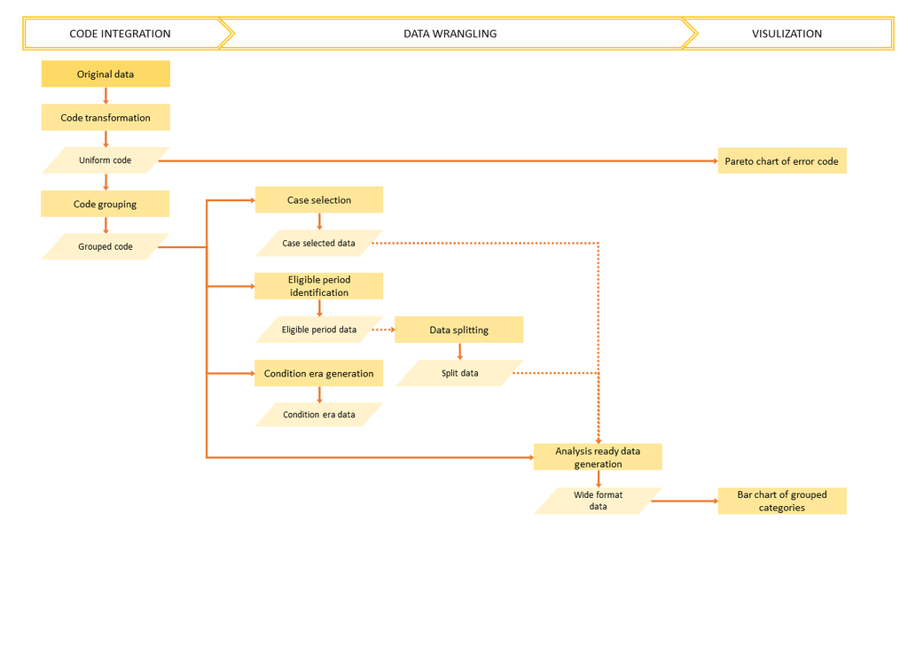

## Installation

```r
install.packages("remotes")
remotes::install_github("DHLab-TSENG/dxpr")
```

## Load packages

```r
library(dxpr)
library(tidyverse)
```

# Learn from a real analysis case!

## Research question

- Newborns who were diagnosed with patent ductus arteriosus (PDA) vs. without PDA
  - Define **PDA** and **non-PDA** groups
- The differences of comorbidity between these two groups
  - Define comorbidity

# Data - MIMIC III

## Example data - from MIMIC III (1/2)

- A large, **freely-available** database
- Deidentified health-related data, over **40,000** patients
- ICU of the Beth Israel Deaconess Medical Center, 2001-2012.
- You must completing **CITI Data or Specimens Only Research** training
- [MIMIC III](https://physionet.org/content/mimiciii/1.4/)

## Example data - from MIMIC III (2/2)

- Demographics
- Vital sign measurements made at the bedside
  - ~1 data point/hr
- Laboratory test results
- Procedures
- Medications
- Caregiver notes, imaging reports
- Mortality (including post-hospital discharge)

## Example data - newborn’s data

- **Admission**: ADMISSIONS
  - Unique hospitalization for each patient in the database `HADM_ID`
  - Use to get a `SUBJECT_ID` list of **newborn**
- **Diagnosis**: DIAGNOSES_ICD
  - Coded using the **I**nternational Statistical **C**lassification of **D**iseases and Related Health Problems (‘ICD’) system
  - Use to analyze comorbidity

## Take a look of the example data

From **DIAGNOSES_ICD** data, only for newborn

```r
sampleNewborn<-readRDS("data/sampleNewborn.rds")
glimpse(sampleNewborn, width = 70)
```

```
Rows: 45,674
Columns: 5
$ SUBJECT_ID <int> 2, 2, 2, 5, 5, 5, 7, 7, 7, 8, 8, 8, 8, 8, 8, 10, …
$ HADM_ID    <int> 163353, 163353, 163353, 178980, 178980, 178980, 1…
$ SEQ_NUM    <int> 1, 2, 3, 1, 2, 3, 1, 2, 3, 1, 2, 3, 4, 5, 6, 1, 2…
$ ICD9_CODE  <chr> "V3001", "V053", "V290", "V3000", "V053", "V290",…
$ ADMITTIME  <date> 2138-07-17, 2138-07-17, 2138-07-17, 2103-02-02, …
```

[Coding book](https://mimic.mit.edu/docs/iii/tables/)

```r
sampleNewborn %>%
  summarise(Subject=n_distinct(SUBJECT_ID),
            Admission=n_distinct(HADM_ID),
            TotalDiagnoses=n())
```

[output not shown]

## Take a look of the data from 1 patient

```r
sampleNewborn %>%
  filter(SUBJECT_ID == 4026)
```

[output not shown]

# Step 1. Select Target Cases

## Define your target

- Research target: newborn who diagnosed with *Patent Ductus Arteriosus* (PDA)
- The ICD-9 code for PDA is 747.0

[figure not shown]

[source](http://www.icd9data.com/2015/Volume1/740-759/747/default.htm)

## Select cases from your data (1/2)

- Use `selectCases()` from `dxpr`
- provide the names of `patient ID`, `ICD`, and `date`
- `icd10usingDate` = “9999/01/01” **The date start using ICD10**
- `groupDataType` = ICD **Use ICD to select cases**
- `caseCondition` = “^7470” **ICD codes for cases**
- `caseCount` = 1 **Most of the time we need more diagnoses**
- `CaseName` = “PDA” **Name for the case group**

## Select cases from your data (2/2)

```r
Case <- selectCases(dxDataFile = sampleNewborn,
                    idColName = SUBJECT_ID,
                    icdColName = ICD9_CODE,
                    dateColName = ADMITTIME,
                    icd10usingDate = "9999/01/01",
                    groupDataType = ICD,
                    caseCondition = "^7470",
                    caseCount = 1,
                    caseName = "PDA")
```

## Warnings from ICD codes analysis

- **Wrong ICD format**: the ICD has wrong format
- **Wrong ICD version**: means the ICD classify to wrong ICD version
- Examples: total 37 ICD codes (the number of occurrences is in brackets) c(“7793 (1024)”, “V721 (368)”, “7708 (221)”, “7473 (106)”, “7775 (60)”, “7718 (47)”, “7671 (28)”, “7701 (23)”, “7806 (12)”, “7798 (9)”)

## Warnings from ICD - why?

- 1024 diagnoses being coded as 7793 (779.3)
- But 779.3 might not be the one used for grouping
- Solution available later

## Select target cases from your data

```r
Case
```

[output not shown]

# Step 2. Identify Comorbidity by Using Diagnoses

## Identify comorbidity - Elixhauser

- Congestive heart failure
- Cardiac arrythmia
- Valvular disease
- Pulmonary circulation disorders
- Peripheral vascular disorders
- Hypertension
- Paralysis
- Neurodegenerative disorder
- Chronic Pulmonary disease
- Uncomplicated diabetes
- Complicated diabetes
- Hypothyrodism
- Renal failure
- Liver disease
- Peptic ulcer disease
- AIDS/HIV
- Lymphoma
- Metastatic cancer
- Solid tumor
- Rheumatoid arthritis diseases
- Coagulopath
- Obesity
- Weight loss
- Fluid and electrolyte disorders
- Blood loss anemia
- Deficiency anemia
- Alcohol abuse
- Drug abuse
- Psychoses
- Depression

[paper](http://dx.doi.org/10.1097/MLR.0b013e31819432e5)

## Identify comorbidity from your data

- Use `icdDxToComorbid` function from `dxpr`
- `comorbidMethod` = elix (`ahrq`, `charlson`, and `elix`)
- `isDescription` = F

```r
Elix <- icdDxToComorbid(dxDataFile = sampleNewborn,
                        idColName = SUBJECT_ID,
                        icdColName = ICD9_CODE,
                        dateColName = ADMITTIME,
                        icd10usingDate = "9999-10-01",
                        comorbidMethod = elix,
                        isDescription = F)
```

## Warnings from ICD codes analysis - solution

```r
head(Elix$Error)
```

[output not shown]

[source](http://www.icd9data.com/2014/Volume1/760-779/764-779/779/default.htm)

## Clean your data

Correct the ICD codes by yourself (choosing the right code)

```r
sampleNewborn$ICD9_CODE<-
  ifelse(sampleNewborn$ICD9_CODE=="7793",
         "77931",sampleNewborn$ICD9_CODE)
sampleNewborn$ICD9_CODE<-
  ifelse(sampleNewborn$ICD9_CODE=="V721",
         "V7219",sampleNewborn$ICD9_CODE)
```

[source](http://www.icd9data.com/2014/Volume1/760-779/764-779/779/default.htm)

## Identify comorbidity - again

```r
Elix <- icdDxToComorbid(dxDataFile = sampleNewborn,
                        idColName = SUBJECT_ID,
                        icdColName = ICD9_CODE,
                        dateColName = ADMITTIME,
                        icd10usingDate = "9999-10-01",
                        comorbidMethod = Elix,
                        isDescription = F)
```

## Check warnings again

```r
head(Elix$Error)
```

[output not shown]

## Check warnings - visualization

```r
ErrorPlot <- plotICDError(errorFile = Elix$Error,
                          icdVersion = all,
                          wrongICDType = all,
                          others = TRUE,
                          topN = 10)
ErrorPlot$graph
```

[output not shown]

## Comorbidity add-on

```r
Elix$groupedDT %>%
  filter(!is.na(Comorbidity))
```

[output not shown]

## Comorbidity summary

```r
Elix$summarised_groupedDT
```

[output not shown]

## Identify comorbidity from your data - CCS (1/2)

```r
CCS <- icdDxToCCS(dxDataFile = sampleNewborn,
                  idColName = SUBJECT_ID,
                  icdColName = ICD9_CODE,
                  dateColName = ADMITTIME,
                  icd10usingDate = "9999-10-01",
                  isDescription = TRUE)
```

## Identify comorbidity from your data - CCS (2/2)

```r
CCS
```

[output not shown]

# Step 3. Generate Analysis-Ready Data

## Wide format transformation (1/2)

- Use `groupedDataLongToWide` function from `dxpr`
- `categoryColName` = Comorbidity **column name**
- `numericOrBinary` = N **Yes or No / Number of diagnoses**
- `selectedCaseFile` = Case **column name**

```r
Elix_wide <-
  groupedDataLongToWide(dxDataFile = Elix$groupedDT,
                        idColName = ID,
                        categoryColName = Comorbidity,
                        dateColName = Date,
                        numericOrBinary = N,
                        selectedCaseFile = Case)
```

## Wide format transformation (2/2)

```r
Elix_wide
```

[output not shown]

# Step 4. Analyze Your Data

## Create the table 1 (1/2)

- `vars`: variables include in the table
- `strata`: grouping variable
- `factorVars`: categorical variables

```r
library(tableone)
var_col <- names(Elix_wide)[2:(length(Elix_wide))]
table_Elix <-
  CreateTableOne(vars = var_col,
                 strata = "selectedCase",
                 data = as.data.frame(Elix_wide),
                 factorVars = var_col)
```

## Create the table 1 (1/2)

```r
table_Elix
```

[output not shown]

## Create the table 1 - easy to C&P

```r
print_table <- print(table_Elix,
                     noSpaces = TRUE,
                     printToggle = FALSE)
write.csv(print_table,"table_Elix.csv")
```

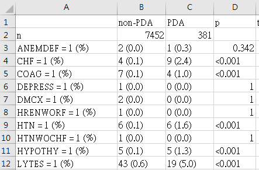

## Create the table 1 - pretty ver. (1/2)

- `gtsummary` is a good package to generate ready to use analysis results
- `tbl_summary` function from `gtsummary` can generate the **table 1**

## Create the table 1 - pretty ver. (2/2)

```r
library(gtsummary)
Elix_wide %>%
  tbl_summary(by = selectedCase) %>%
  add_p()
```

[output not shown]

## Visualize table 1

- `topN` = 10 **n most common group**
- `limitFreq` = 0.01 **minimum frequency shown**

```r
DiagCatPlot<-
  plotDiagCat(groupedDataWide = Elix_wide,
              idColName = ID,
              groupColName = selectedCase,
              topN = 10,
              limitFreq = 0.01)
DiagCatPlot$graph
```

[output not shown]

## Build models (1/2)

Basic logistic regression model

```r
Elix_wide$selectedCase<-
  factor(Elix_wide$selectedCase,levels=c("non-PDA","PDA"))
fit <- glm(selectedCase ~ CHF+COAG+HTN+HYPOTHY+LYTES+NEURO+PULMCIRC+VALVE,
           Elix_wide, family = binomial)
summary(fit)$coefficients
```

[output not shown]

## Build models (2/2)

- `tbl_regression` function from `gtsummary` can generate the OR table for multiple variables regression

```r
tbl_regression(fit, exponentiate = TRUE)
```

[output not shown]

## References - I. Code transformation

ICD-9-CM code (2014): https://www.cms.gov/Medicare/Coding/ICD9ProviderDiagnosticCodes/codes.html

ICD-10-CM code (2019-2022):

https://www.cms.gov/Medicare/Coding/ICD10

https://www.findacode.com/search/search.php

https://www.cms.gov/Medicare/Quality-Initiatives-Patient-Assessment-Instruments/HospitalQualityInits/Downloads/HospitalAppendix_F.pdf

## References - II. Code grouping, CCS

**CCS (Clinical Classifications Software)**

ICD-9-CM (2015):

https://www.hcup-us.ahrq.gov/toolssoftware/ccs/ccs.jsp

https://www.hcup-us.ahrq.gov/toolssoftware/ccs/Multi_Level_CCS_2015.zip

ICD-10-CM (2019):

https://www.hcup-us.ahrq.gov/toolssoftware/ccsr/ccsr_archive.jsp

https://www.hcup-us.ahrq.gov/toolssoftware/ccs10/ccs_dx_icd10cm_2019_1.zip

## References - II. Code grouping, Comorbidities

ICD-9-AHRQ (2012-2015): https://www.hcup-us.ahrq.gov/toolssoftware/comorbidity/comorbidity.jsp#references

ICD-10-AHRQ (2019): https://www.hcup-us.ahrq.gov/toolssoftware/comorbidityicd10/comformat_icd10cm_2019_1.txt

ICD-9-Charlson: http://mchp-appserv.cpe.umanitoba.ca/Upload/SAS/ICD9_E\_Charlson.sas.txt

ICD-10-Charlson: http://mchp-appserv.cpe.umanitoba.ca/Upload/SAS/ICD10_Charlson.sas.txt

ICD-9-Elixhauser (2012-2015): https://www.hcup-us.ahrq.gov/toolssoftware/comorbidity/comorbidity.jsp#references

ICD-10-Elixhauser (2019): https://www.hcup-us.ahrq.gov/toolssoftware/comorbidityicd10/comformat_icd10cm_2019_1.txt

## References - II. Code grouping, Others

**CCSR (Clinical Classifications Software Refined)**

ICD-10-CM (v2022-1): https://www.hcup-us.ahrq.gov/toolssoftware/ccsr/ccs_refined.jsp

**PheWAS**

ICD-9-Phecode (version 1.2, 2015): https://phewascatalog.org/phecodes

ICD-10 Phecode (version 1.2 beta, 2019): https://phewascatalog.org/phecodes_icd10cm